# Resumen Tidyverse a vista de pájaro para EncuentRos en la fase R de R Hispano

Luis Morís Fernández y Joaquín Morís

Este fichero de RMarkdown contiene todo el código usado en la presentación ‘Tidyevrse a vista de pájaro’ que realizamos en [EncuentRos en la fase R](https://www.u-tad.com/event/save-the-date-encuentros-r/), tanto [Luis](https://es.linkedin.com/in/luis-moris-fernandez) como [yo mismo](https://twitter.com/joaquinmoris).

Para cualquier cosa, puedes ponerte en contacto con nosotros a través de los correos que aparecen en la presentación

### Tidyverse a vista de pájaro

Esta es una breve presentación de los verbos más importantes de dplyr. Vamos a empezar cargando el conjunto de librerías de tidyverse, y vamos a utilizar el set de datos `palmerpenguins` que contiene información sobre pingüinos de varias islas.

```r
library(tidyverse)
library(palmerpenguins)
```

```r
citation("palmerpenguins")
```

```
##
##
##   Horst AM, Hill AP, Gorman KB (2020). palmerpenguins: Palmer Archipelago (Antarctica) penguin data. R package version 0.1.0. https://allisonhorst.github.io/palmerpenguins/
##
## A BibTeX entry for LaTeX users is
##
##   @Manual{,
##     title = {palmerpenguins: Palmer Archipelago (Antarctica) penguin data},
##     author = {Allison Marie Horst and Alison Presmanes Hill and Kristen B Gorman},
##     year = {2020},
##     note = {R package version 0.1.0},
##     url = {https://allisonhorst.github.io/palmerpenguins/},
##   }
```

La primera función que vamos a utilizar es `glimpse`, que ofrece un resumen de un data.frame o un tibble. Es una versión mejorada de la función `str` de R base. Rápidamente podemos ver que nuestro tibble contiene 344 observaciones y 8 variables, el nombre de las variables y su tipo (factor, numérico, carácter, etc.)

```r
dplyr::glimpse(as.data.frame(penguins))
```

```
## Rows: 344
## Columns: 8
## $ species           <fct> Adelie, Adelie, Adelie, Adelie, Adelie, Adelie, Adelie, Adelie, Adelie, Adelie, Adelie, Adelie, Adelie, Adelie, Adelie, Adelie, Adelie, Adelie, Adelie, Adelie, Adelie, Adelie, Adelie, Adelie, Adelie, Adelie, Adelie, Adelie, Adelie, Adelie, Adelie, Adelie, Adelie, Adeli..…
## $ island            <fct> Torgersen, Torgersen, Torgersen, Torgersen, Torgersen, Torgersen, Torgersen, Torgersen, Torgersen, Torgersen, Torgersen, Torgersen, Torgersen, Torgersen, Torgersen, Torgersen, Torgersen, Torgersen, Torgersen, Torgersen, Biscoe, Biscoe, Biscoe, Biscoe, Biscoe, Biscoe, B..…
## $ bill_length_mm    <dbl> 39.1, 39.5, 40.3, NA, 36.7, 39.3, 38.9, 39.2, 34.1, 42.0, 37.8, 37.8, 41.1, 38.6, 34.6, 36.6, 38.7, 42.5, 34.4, 46.0, 37.8, 37.7, 35.9, 38.2, 38.8, 35.3, 40.6, 40.5, 37.9, 40.5, 39.5, 37.2, 39.5, 40.9, 36.4, 39.2, 38.8, 42.2, 37.6, 39.8, 36.5, 40.8, 36.0, 44.1, 37.0, 3..…
## $ bill_depth_mm     <dbl> 18.7, 17.4, 18.0, NA, 19.3, 20.6, 17.8, 19.6, 18.1, 20.2, 17.1, 17.3, 17.6, 21.2, 21.1, 17.8, 19.0, 20.7, 18.4, 21.5, 18.3, 18.7, 19.2, 18.1, 17.2, 18.9, 18.6, 17.9, 18.6, 18.9, 16.7, 18.1, 17.8, 18.9, 17.0, 21.1, 20.0, 18.5, 19.3, 19.1, 18.0, 18.4, 18.5, 19.7, 16.9, 1..…
## $ flipper_length_mm <int> 181, 186, 195, NA, 193, 190, 181, 195, 193, 190, 186, 180, 182, 191, 198, 185, 195, 197, 184, 194, 174, 180, 189, 185, 180, 187, 183, 187, 172, 180, 178, 178, 188, 184, 195, 196, 190, 180, 181, 184, 182, 195, 186, 196, 185, 190, 182, 179, 190, 191, 186, 188, 190, 200, ..…
## $ body_mass_g       <int> 3750, 3800, 3250, NA, 3450, 3650, 3625, 4675, 3475, 4250, 3300, 3700, 3200, 3800, 4400, 3700, 3450, 4500, 3325, 4200, 3400, 3600, 3800, 3950, 3800, 3800, 3550, 3200, 3150, 3950, 3250, 3900, 3300, 3900, 3325, 4150, 3950, 3550, 3300, 4650, 3150, 3900, 3100, 4400, 3000, 4..…
## $ sex               <fct> male, female, female, NA, female, male, female, male, NA, NA, NA, NA, female, male, male, female, female, male, female, male, female, male, female, male, male, female, male, female, female, male, female, male, female, male, female, male, male, female, female, male, fem..…
## $ year              <int> 2007, 2007, 2007, 2007, 2007, 2007, 2007, 2007, 2007, 2007, 2007, 2007, 2007, 2007, 2007, 2007, 2007, 2007, 2007, 2007, 2007, 2007, 2007, 2007, 2007, 2007, 2007, 2007, 2007, 2007, 2007, 2007, 2007, 2007, 2007, 2007, 2007, 2007, 2007, 2007, 2007, 2007, 2007, 2007, 2007,..…
```

Vamos a utilizar por primera vez los pipes de `magrittr`. El resultado de cada función se pasa mediante el pipe y se convierte en el primer parámetro de la siguiente función. Así, `f(x, y)` sería equivalente a `x %>% f(y)`.

```r
penguins %>%
  is_tibble()
```

```
## [1] TRUE
```

Podemos unir tantos comandos con pipes como queramos. ¿Hay alguna longitud de pico que tenga un valor NA? En este caso vamos a partir de la longitud de picos de los picos, vamos a ver si cada uno de ellos es un NA o no, y por último, la función `any` evaluará si alguno de los valores es TRUE.

```r
penguins$bill_length_mm %>%
  is.na() %>%
  any()
```

```
## [1] TRUE
```

# ¿Qué pasa si tenemos que añadir más parámetros a la llamada de la función? Podemos añadirlos tanto por nombre como por posición.

```r
penguins$bill_length_mm %>%
  mean(na.rm = TRUE)
```

```
## [1] 43.92193
```

En este caso, el primer parámetro de `head` sería `penguins`, y el segundo, 10.

```r
penguins %>% head(10)
```

```
## # A tibble: 10 x 8
##    species island    bill_length_mm bill_depth_mm flipper_length_mm body_mass_g sex     year
##    <fct>   <fct>              <dbl>         <dbl>             <int>       <int> <fct>  <int>
##  1 Adelie  Torgersen           39.1          18.7               181        3750 male    2007
##  2 Adelie  Torgersen           39.5          17.4               186        3800 female  2007
##  3 Adelie  Torgersen           40.3          18                 195        3250 female  2007
##  4 Adelie  Torgersen           NA            NA                  NA          NA <NA>    2007
##  5 Adelie  Torgersen           36.7          19.3               193        3450 female  2007
##  6 Adelie  Torgersen           39.3          20.6               190        3650 male    2007
##  7 Adelie  Torgersen           38.9          17.8               181        3625 female  2007
##  8 Adelie  Torgersen           39.2          19.6               195        4675 male    2007
##  9 Adelie  Torgersen           34.1          18.1               193        3475 <NA>    2007
## 10 Adelie  Torgersen           42            20.2               190        4250 <NA>    2007
```

El primer verbo que vamos a ver es `select`, que permite seleccionar columnas. En este caso vamos a quedarnos solamente con las variables species y year.

```r
penguins %>%
  select(species, year)
```

```
## # A tibble: 344 x 2
##    species  year
##    <fct>   <int>
##  1 Adelie   2007
##  2 Adelie   2007
##  3 Adelie   2007
##  4 Adelie   2007
##  5 Adelie   2007
##  6 Adelie   2007
##  7 Adelie   2007
##  8 Adelie   2007
##  9 Adelie   2007
## 10 Adelie   2007
## # ... with 334 more rows
```

También podemos hacer una selección negativa, indicando que columnas queremos eliminar. En este caso queremos todas las variables excepto year y species.

```r
penguins %>%
  select (-year, -species)
```

```
## # A tibble: 344 x 6
##    island    bill_length_mm bill_depth_mm flipper_length_mm body_mass_g sex
##    <fct>              <dbl>         <dbl>             <int>       <int> <fct>
##  1 Torgersen           39.1          18.7               181        3750 male
##  2 Torgersen           39.5          17.4               186        3800 female
##  3 Torgersen           40.3          18                 195        3250 female
##  4 Torgersen           NA            NA                  NA          NA <NA>
##  5 Torgersen           36.7          19.3               193        3450 female
##  6 Torgersen           39.3          20.6               190        3650 male
##  7 Torgersen           38.9          17.8               181        3625 female
##  8 Torgersen           39.2          19.6               195        4675 male
##  9 Torgersen           34.1          18.1               193        3475 <NA>
## 10 Torgersen           42            20.2               190        4250 <NA>
## # ... with 334 more rows
```

También podemos hacer selecciones dependiendo de condiciones lógicas, usando `where`, en este caso vamos a quedarnos solamenet con aquellas variables que sean numéricas.

```r
penguins %>%
  select(where(is.numeric))
```

```
## # A tibble: 344 x 5
##    bill_length_mm bill_depth_mm flipper_length_mm body_mass_g  year
##             <dbl>         <dbl>             <int>       <int> <int>
##  1           39.1          18.7               181        3750  2007
##  2           39.5          17.4               186        3800  2007
##  3           40.3          18                 195        3250  2007
##  4           NA            NA                  NA          NA  2007
##  5           36.7          19.3               193        3450  2007
##  6           39.3          20.6               190        3650  2007
##  7           38.9          17.8               181        3625  2007
##  8           39.2          19.6               195        4675  2007
##  9           34.1          18.1               193        3475  2007
## 10           42            20.2               190        4250  2007
## # ... with 334 more rows
```

También podemos seleccionar tramos de variables, en este caso todas las variables que van desde la longitud de las aletas hasta el año de observación.

```r
penguins %>%
  select(flipper_length_mm:year)
```

```
## # A tibble: 344 x 4
##    flipper_length_mm body_mass_g sex     year
##                <int>       <int> <fct>  <int>
##  1               181        3750 male    2007
##  2               186        3800 female  2007
##  3               195        3250 female  2007
##  4                NA          NA <NA>    2007
##  5               193        3450 female  2007
##  6               190        3650 male    2007
##  7               181        3625 female  2007
##  8               195        4675 male    2007
##  9               193        3475 <NA>    2007
## 10               190        4250 <NA>    2007
## # ... with 334 more rows
```

## Filter

Cuando queremos quedarnos con tan solo algunos casos, podemos utilizar el verbo `filter`. En este caso vamos a quedarnos solamente con los casos en los que la isla sea Dream.

```r
penguins %>%
  filter(island == "Dream")
```

```
## # A tibble: 124 x 8
##    species island bill_length_mm bill_depth_mm flipper_length_mm body_mass_g sex     year
##    <fct>   <fct>           <dbl>         <dbl>             <int>       <int> <fct>  <int>
##  1 Adelie  Dream            39.5          16.7               178        3250 female  2007
##  2 Adelie  Dream            37.2          18.1               178        3900 male    2007
##  3 Adelie  Dream            39.5          17.8               188        3300 female  2007
##  4 Adelie  Dream            40.9          18.9               184        3900 male    2007
##  5 Adelie  Dream            36.4          17                 195        3325 female  2007
##  6 Adelie  Dream            39.2          21.1               196        4150 male    2007
##  7 Adelie  Dream            38.8          20                 190        3950 male    2007
##  8 Adelie  Dream            42.2          18.5               180        3550 female  2007
##  9 Adelie  Dream            37.6          19.3               181        3300 female  2007
## 10 Adelie  Dream            39.8          19.1               184        4650 male    2007
## # ... with 114 more rows
```

Pero podemos poner tantas condiciones como queramos, y es fácil de leer que es lo que estamos haciendo. Aquí queremos casos de la especie Adelie, con año de observación posterior a 2007, que tengan o un pico inferior a 40mm o una aleta de longitud superior a 182mm, y cuya masa corporal sea inferior a la media del masa corporal de todo el dataset. Es más largo y complicado explicarlo en texto que leer directamente el código…

```r
penguins %>%
  filter(species == "Adelie",
         year > 2007,
         bill_length_mm < 40 | flipper_length_mm > 182,
         body_mass_g < mean(body_mass_g, na.rm = TRUE))
```

```
## # A tibble: 83 x 8
##    species island bill_length_mm bill_depth_mm flipper_length_mm body_mass_g sex     year
##    <fct>   <fct>           <dbl>         <dbl>             <int>       <int> <fct>  <int>
##  1 Adelie  Biscoe           39.6          17.7               186        3500 female  2008
##  2 Adelie  Biscoe           35            17.9               190        3450 female  2008
##  3 Adelie  Biscoe           42            19.5               200        4050 male    2008
##  4 Adelie  Biscoe           34.5          18.1               187        2900 female  2008
##  5 Adelie  Biscoe           41.4          18.6               191        3700 male    2008
##  6 Adelie  Biscoe           39            17.5               186        3550 female  2008
##  7 Adelie  Biscoe           40.6          18.8               193        3800 male    2008
##  8 Adelie  Biscoe           36.5          16.6               181        2850 female  2008
##  9 Adelie  Biscoe           37.6          19.1               194        3750 male    2008
## 10 Adelie  Biscoe           35.7          16.9               185        3150 female  2008
## # ... with 73 more rows
```

## Muestrear

Tenemos dos funciones que nos permiten extraer muestras aleatorias, en el caso de `sample_frac` muestramos una proporción, en el ejemplo de debajo el 10% del dataset.

```r
penguins %>%
  sample_frac(0.1)
```

```
## # A tibble: 34 x 8
##    species   island bill_length_mm bill_depth_mm flipper_length_mm body_mass_g sex     year
##    <fct>     <fct>           <dbl>         <dbl>             <int>       <int> <fct>  <int>
##  1 Gentoo    Biscoe           46.2          14.5               209        4800 female  2007
##  2 Adelie    Dream            32.1          15.5               188        3050 female  2009
##  3 Chinstrap Dream            49.2          18.2               195        4400 male    2007
##  4 Adelie    Dream            41.1          18.1               205        4300 male    2008
##  5 Gentoo    Biscoe           48.2          15.6               221        5100 male    2008
##  6 Adelie    Biscoe           39.7          18.9               184        3550 male    2009
##  7 Chinstrap Dream            58            17.8               181        3700 female  2007
##  8 Gentoo    Biscoe           49.6          16                 225        5700 male    2008
##  9 Gentoo    Biscoe           42            13.5               210        4150 female  2007
## 10 Gentoo    Biscoe           46.5          14.8               217        5200 female  2008
## # ... with 24 more rows
```

Si usamos `sample_n` muestreamos un número fijo de casos, 10 en el ejemplo de debajo.

```r
penguins %>%
  sample_n(10)
```

```
## # A tibble: 10 x 8
##    species   island bill_length_mm bill_depth_mm flipper_length_mm body_mass_g sex     year
##    <fct>     <fct>           <dbl>         <dbl>             <int>       <int> <fct>  <int>
##  1 Adelie    Biscoe           41.1          19.1               188        4100 male    2008
##  2 Adelie    Biscoe           37.9          18.6               193        2925 female  2009
##  3 Gentoo    Biscoe           48.8          16.2               222        6000 male    2009
##  4 Gentoo    Biscoe           49.1          15                 228        5500 male    2009
##  5 Adelie    Biscoe           40.6          18.6               183        3550 male    2007
##  6 Chinstrap Dream            46.4          17.8               191        3700 female  2008
##  7 Adelie    Dream            41.3          20.3               194        3550 male    2008
##  8 Gentoo    Biscoe           45.3          13.8               208        4200 female  2008
##  9 Gentoo    Biscoe           45.2          16.4               223        5950 male    2008
## 10 Gentoo    Biscoe           44.5          14.7               214        4850 female  2009
```

## Mutate

El verbo `mutate` nos permite calcular nuevas variables o modificar variables que ya existen. Por ejemplo, si queremos una nueva variable en la que se almacenen los valores de los nombres de isla como cadenas de caracteres en vez de como factor, usaríamos este verbo.

```r
penguins %>%
  mutate(island_char = as.character(island))
```

```
## # A tibble: 344 x 9
##    species island    bill_length_mm bill_depth_mm flipper_length_mm body_mass_g sex     year island_char
##    <fct>   <fct>              <dbl>         <dbl>             <int>       <int> <fct>  <int> <chr>
##  1 Adelie  Torgersen           39.1          18.7               181        3750 male    2007 Torgersen
##  2 Adelie  Torgersen           39.5          17.4               186        3800 female  2007 Torgersen
##  3 Adelie  Torgersen           40.3          18                 195        3250 female  2007 Torgersen
##  4 Adelie  Torgersen           NA            NA                  NA          NA <NA>    2007 Torgersen
##  5 Adelie  Torgersen           36.7          19.3               193        3450 female  2007 Torgersen
##  6 Adelie  Torgersen           39.3          20.6               190        3650 male    2007 Torgersen
##  7 Adelie  Torgersen           38.9          17.8               181        3625 female  2007 Torgersen
##  8 Adelie  Torgersen           39.2          19.6               195        4675 male    2007 Torgersen
##  9 Adelie  Torgersen           34.1          18.1               193        3475 <NA>    2007 Torgersen
## 10 Adelie  Torgersen           42            20.2               190        4250 <NA>    2007 Torgersen
## # ... with 334 more rows
```

Podemos hacer más de una transformación, por ejemplo podemos pasar el nombre de las islas a caracteres y después ponerlos en mayúsuculas.

```r
penguins %>%
  mutate(island_upper = as.character(island) %>% toupper())
```

```
## # A tibble: 344 x 9
##    species island    bill_length_mm bill_depth_mm flipper_length_mm body_mass_g sex     year island_upper
##    <fct>   <fct>              <dbl>         <dbl>             <int>       <int> <fct>  <int> <chr>
##  1 Adelie  Torgersen           39.1          18.7               181        3750 male    2007 TORGERSEN
##  2 Adelie  Torgersen           39.5          17.4               186        3800 female  2007 TORGERSEN
##  3 Adelie  Torgersen           40.3          18                 195        3250 female  2007 TORGERSEN
##  4 Adelie  Torgersen           NA            NA                  NA          NA <NA>    2007 TORGERSEN
##  5 Adelie  Torgersen           36.7          19.3               193        3450 female  2007 TORGERSEN
##  6 Adelie  Torgersen           39.3          20.6               190        3650 male    2007 TORGERSEN
##  7 Adelie  Torgersen           38.9          17.8               181        3625 female  2007 TORGERSEN
##  8 Adelie  Torgersen           39.2          19.6               195        4675 male    2007 TORGERSEN
##  9 Adelie  Torgersen           34.1          18.1               193        3475 <NA>    2007 TORGERSEN
## 10 Adelie  Torgersen           42            20.2               190        4250 <NA>    2007 TORGERSEN
## # ... with 334 more rows
```

Supongamos que los valores de longitud del pico por debajo de 37 son un error de medida y los queremos corregir. Ahora el `mutate` debe ser condicional. Lo podemos hacer usando la función de `dplyr` `if_else`, que de manera vectorizada evalua una condición, y devuelve un valor cuando la condición sea verdadera y otra cuando sea falsa. En este caso, cuando la longitud del pico sea inferior a 37 se cambia ese valor a 37, pero cuando sea igual o mayor, se mantiene el valor original.

```r
penguins %>%
  mutate (bill_length_mm = if_else(bill_length_mm < 37,
                                true = 37,
                                false = bill_length_mm))
```

```
## # A tibble: 344 x 8
##    species island    bill_length_mm bill_depth_mm flipper_length_mm body_mass_g sex     year
##    <fct>   <fct>              <dbl>         <dbl>             <int>       <int> <fct>  <int>
##  1 Adelie  Torgersen           39.1          18.7               181        3750 male    2007
##  2 Adelie  Torgersen           39.5          17.4               186        3800 female  2007
##  3 Adelie  Torgersen           40.3          18                 195        3250 female  2007
##  4 Adelie  Torgersen           NA            NA                  NA          NA <NA>    2007
##  5 Adelie  Torgersen           37            19.3               193        3450 female  2007
##  6 Adelie  Torgersen           39.3          20.6               190        3650 male    2007
##  7 Adelie  Torgersen           38.9          17.8               181        3625 female  2007
##  8 Adelie  Torgersen           39.2          19.6               195        4675 male    2007
##  9 Adelie  Torgersen           37            18.1               193        3475 <NA>    2007
## 10 Adelie  Torgersen           42            20.2               190        4250 <NA>    2007
## # ... with 334 more rows
```

También podemos aplicar funciones que acabemos de definir. Por ejemplo, si queremos pasar de milímetros a metros, podemos utilizar `across`, que nos permite hacer una selección de variables, en este caso todas las que tengan nombres que terminan en “mm”, y transformarlas, diviendo sus valores por 1000.

```r
to_meters <- function(x){
  x/1000
}

penguins %>%
  mutate(across(ends_with("mm"), to_meters))
```

```
## # A tibble: 344 x 8
##    species island    bill_length_mm bill_depth_mm flipper_length_mm body_mass_g sex     year
##    <fct>   <fct>              <dbl>         <dbl>             <dbl>       <int> <fct>  <int>
##  1 Adelie  Torgersen         0.0391        0.0187             0.181        3750 male    2007
##  2 Adelie  Torgersen         0.0395        0.0174             0.186        3800 female  2007
##  3 Adelie  Torgersen         0.0403        0.018              0.195        3250 female  2007
##  4 Adelie  Torgersen        NA            NA                 NA              NA <NA>    2007
##  5 Adelie  Torgersen         0.0367        0.0193             0.193        3450 female  2007
##  6 Adelie  Torgersen         0.0393        0.0206             0.19         3650 male    2007
##  7 Adelie  Torgersen         0.0389        0.0178             0.181        3625 female  2007
##  8 Adelie  Torgersen         0.0392        0.0196             0.195        4675 male    2007
##  9 Adelie  Torgersen         0.0341        0.0181             0.193        3475 <NA>    2007
## 10 Adelie  Torgersen         0.042         0.0202             0.19         4250 <NA>    2007
## # ... with 334 more rows
```

## Rename

Otras veces querremos cambiar el nombre de una o más variables. Si queremos que la variable `year` pasara a llamarse `observation_year`, lo haríamos con `rename`

```r
penguins %>%
  rename(observation_year = year)
```

```
## # A tibble: 344 x 8
##    species island    bill_length_mm bill_depth_mm flipper_length_mm body_mass_g sex    observation_year
##    <fct>   <fct>              <dbl>         <dbl>             <int>       <int> <fct>             <int>
##  1 Adelie  Torgersen           39.1          18.7               181        3750 male               2007
##  2 Adelie  Torgersen           39.5          17.4               186        3800 female             2007
##  3 Adelie  Torgersen           40.3          18                 195        3250 female             2007
##  4 Adelie  Torgersen           NA            NA                  NA          NA <NA>               2007
##  5 Adelie  Torgersen           36.7          19.3               193        3450 female             2007
##  6 Adelie  Torgersen           39.3          20.6               190        3650 male               2007
##  7 Adelie  Torgersen           38.9          17.8               181        3625 female             2007
##  8 Adelie  Torgersen           39.2          19.6               195        4675 male               2007
##  9 Adelie  Torgersen           34.1          18.1               193        3475 <NA>               2007
## 10 Adelie  Torgersen           42            20.2               190        4250 <NA>               2007
## # ... with 334 more rows
```

Usando `rename_with` podemos aplicar funciones para el renombrado. Cuando antes pasábamos de milímetros a metros con nuestra función `to_meters`, los nombres de las variables seguían siendo los mismos, pero esto es incorrecto, y deberían terminar con “meters” en vez de “mm”. Si llamamos primero a `mutate`, luego podemos usar `rename_with` y en aquellas variables que terminan en “mm”, cambiar ese fin a “meter”.

```r
penguins %>%
  mutate(across(ends_with("mm"), to_meters)) %>%
  rename_with(~ str_replace(string = .x,
                           pattern = "mm$",
                           replacement = "meters"))
```

```
## # A tibble: 344 x 8
##    species island    bill_length_meters bill_depth_meters flipper_length_meters body_mass_g sex     year
##    <fct>   <fct>                  <dbl>             <dbl>                 <dbl>       <int> <fct>  <int>
##  1 Adelie  Torgersen             0.0391            0.0187                 0.181        3750 male    2007
##  2 Adelie  Torgersen             0.0395            0.0174                 0.186        3800 female  2007
##  3 Adelie  Torgersen             0.0403            0.018                  0.195        3250 female  2007
##  4 Adelie  Torgersen            NA                NA                     NA              NA <NA>    2007
##  5 Adelie  Torgersen             0.0367            0.0193                 0.193        3450 female  2007
##  6 Adelie  Torgersen             0.0393            0.0206                 0.19         3650 male    2007
##  7 Adelie  Torgersen             0.0389            0.0178                 0.181        3625 female  2007
##  8 Adelie  Torgersen             0.0392            0.0196                 0.195        4675 male    2007
##  9 Adelie  Torgersen             0.0341            0.0181                 0.193        3475 <NA>    2007
## 10 Adelie  Torgersen             0.042             0.0202                 0.19         4250 <NA>    2007
## # ... with 334 more rows
```

## Summarise

También podemos querer calcular valores agregados a partir del dataset, como podría ser la media de una variable numérica. Para hacer esto podemos usar el verbo `summarise`, en el que indicamos como se llamará la nueva variable y como se calcula.

```r
penguins %>%
  summarise(mean_mass = mean(body_mass_g, na.rm = TRUE))
```

```
## # A tibble: 1 x 1
##   mean_mass
##       <dbl>
## 1     4202.
```

Podemos calcular más de un agregado a la vez, por ejemplo una media y una desviación típica.

```r
penguins %>%
  summarise(mean_mass = mean(body_mass_g, na.rm = TRUE),
            sd_mass = sd(body_mass_g, na.rm = TRUE))
```

```
## # A tibble: 1 x 2
##   mean_mass sd_mass
##       <dbl>   <dbl>
## 1     4202.    802.
```

Dentro de `summarise` podemos usar también `across`, y por ejemplo calcular un estadístico para variables numéricas y otro para variables que sean factores, además de agregados para el conjunto del dataset.

```r
penguins %>%
  summarise(
    across(where(is.numeric), mean, na.rm = TRUE),
    across(where(is.factor), nlevels),
    n = n(),
  )
```

```
## # A tibble: 1 x 9
##   bill_length_mm bill_depth_mm flipper_length_mm body_mass_g  year species island   sex     n
##            <dbl>         <dbl>             <dbl>       <dbl> <dbl>   <int>  <int> <int> <int>
## 1           43.9          17.2              201.       4202. 2008.       3      3     2   344
```

## Group_by

Hasta ahora hemos tratado nuestro dataset en conjunto, pero hay veces que queremos que las distintas operaciones se apliquen a distintos grupos. Por ejemplo, podemos querer calcular la media de cada una de las especies. Para ello, podemos usar el verbo `group_by`. En el ejemplo de debajo primero agrupamos el dataset por las especies, y luego calculamos la media para cada una de ellas.

```r
penguins %>%
  group_by(species) %>%
  summarise(mean_mass = mean(body_mass_g, na.rm = TRUE))
```

```
## # A tibble: 3 x 2
##   species   mean_mass
##   <fct>         <dbl>
## 1 Adelie        3701.
## 2 Chinstrap     3733.
## 3 Gentoo        5076.
```

Podemos hacerlo cruzando más de una variable, por ejemplo cada especie por isla.

```r
penguins %>%
  group_by(species, island) %>%
  summarise(mean_mass = mean(body_mass_g, na.rm = TRUE))
```

```
## # A tibble: 5 x 3
## # Groups:   species [3]
##   species   island    mean_mass
##   <fct>     <fct>         <dbl>
## 1 Adelie    Biscoe        3710.
## 2 Adelie    Dream         3688.
## 3 Adelie    Torgersen     3706.
## 4 Chinstrap Dream         3733.
## 5 Gentoo    Biscoe        5076.
```

## Arrange

Cuando queramos ordenar nuestro dataset podemos usar el verbo `arrange`, por ejemplo ordenando los pingüinos por su masa corporal de manera ascendente.

```r
penguins %>%
  arrange(body_mass_g)
```

```
## # A tibble: 344 x 8
##    species   island    bill_length_mm bill_depth_mm flipper_length_mm body_mass_g sex     year
##    <fct>     <fct>              <dbl>         <dbl>             <int>       <int> <fct>  <int>
##  1 Chinstrap Dream               46.9          16.6               192        2700 female  2008
##  2 Adelie    Biscoe              36.5          16.6               181        2850 female  2008
##  3 Adelie    Biscoe              36.4          17.1               184        2850 female  2008
##  4 Adelie    Biscoe              34.5          18.1               187        2900 female  2008
##  5 Adelie    Dream               33.1          16.1               178        2900 female  2008
##  6 Adelie    Torgersen           38.6          17                 188        2900 female  2009
##  7 Chinstrap Dream               43.2          16.6               187        2900 female  2007
##  8 Adelie    Biscoe              37.9          18.6               193        2925 female  2009
##  9 Adelie    Dream               37.5          18.9               179        2975 <NA>    2007
## 10 Adelie    Dream               37            16.9               185        3000 female  2007
## # ... with 334 more rows
```

Podemos usar dos o más variables para ordenar de manera jerárquica, por ejemplo, primero por año, y dentro de cada año por la longitud del pico.

```r
penguins %>%
  arrange(year, bill_length_mm)
```

```
## # A tibble: 344 x 8
##    species island    bill_length_mm bill_depth_mm flipper_length_mm body_mass_g sex     year
##    <fct>   <fct>              <dbl>         <dbl>             <int>       <int> <fct>  <int>
##  1 Adelie  Torgersen           34.1          18.1               193        3475 <NA>    2007
##  2 Adelie  Torgersen           34.4          18.4               184        3325 female  2007
##  3 Adelie  Torgersen           34.6          21.1               198        4400 male    2007
##  4 Adelie  Biscoe              35.3          18.9               187        3800 female  2007
##  5 Adelie  Biscoe              35.9          19.2               189        3800 female  2007
##  6 Adelie  Dream               36            18.5               186        3100 female  2007
##  7 Adelie  Dream               36            17.9               190        3450 female  2007
##  8 Adelie  Dream               36.4          17                 195        3325 female  2007
##  9 Adelie  Dream               36.5          18                 182        3150 female  2007
## 10 Adelie  Torgersen           36.6          17.8               185        3700 female  2007
## # ... with 334 more rows
```

Cuando queramos que el orden sea descendente tenemos la función `desc`.

```r
penguins %>%
  arrange(desc(body_mass_g))
```

```
## # A tibble: 344 x 8
##    species island bill_length_mm bill_depth_mm flipper_length_mm body_mass_g sex    year
##    <fct>   <fct>           <dbl>         <dbl>             <int>       <int> <fct> <int>
##  1 Gentoo  Biscoe           49.2          15.2               221        6300 male   2007
##  2 Gentoo  Biscoe           59.6          17                 230        6050 male   2007
##  3 Gentoo  Biscoe           51.1          16.3               220        6000 male   2008
##  4 Gentoo  Biscoe           48.8          16.2               222        6000 male   2009
##  5 Gentoo  Biscoe           45.2          16.4               223        5950 male   2008
##  6 Gentoo  Biscoe           49.8          15.9               229        5950 male   2009
##  7 Gentoo  Biscoe           48.4          14.6               213        5850 male   2007
##  8 Gentoo  Biscoe           49.3          15.7               217        5850 male   2007
##  9 Gentoo  Biscoe           55.1          16                 230        5850 male   2009
## 10 Gentoo  Biscoe           49.5          16.2               229        5800 male   2008
## # ... with 334 more rows
```

## Enlazando todo

Lo interesante de manera flexible y sencilla cada uno de estos pasos. Si queremos un gráfico en el que se represente el número de pingüinos hembra que se registra en cada isla por año, podemos usar varios de los verbos que hemos visto y pasarle estos datos a `ggplot`

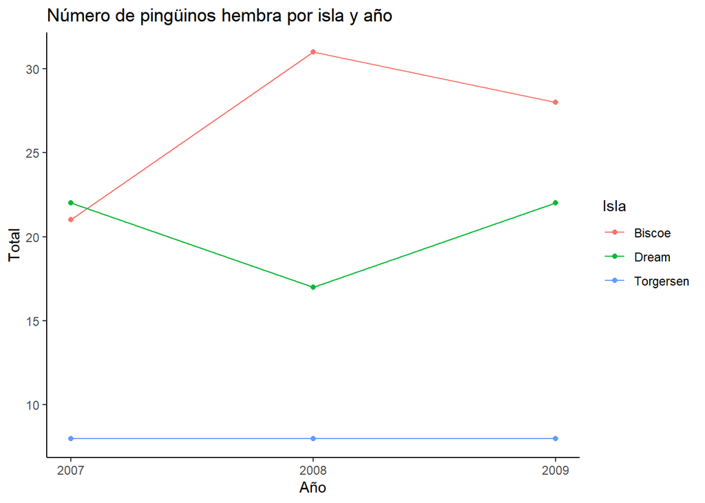

```r
penguins %>%
  filter(sex == "female") %>%
  group_by(island, year) %>%
  summarise(frequency = n()) %>%
  ggplot(aes(x = year, y = frequency, color = island, group = island)) +
  geom_line() +
  geom_point() +
  labs (title = "Número de pingüinos hembra por isla y año", x = "Año", y = "Total", color = "Isla") +
  scale_x_continuous(breaks = 2007:2009) +
  theme_classic()
```

## Gracias por haber llegado hasta aquí

Para cualquier duda o cosa que quieras tratar, puedes escribirnos a luis.moris.fernandez en gmail.com o a joaquin.moris en gmail.com